# unravel

[figure not shown]

Hairballs, hairballs everywhere. Most complex networks are plot in an (arguably) awe-inspiring, questionably informative way, that we should call “a ball of yarn” (Guðmundsdóttir B. [Unravel](https://invidio.us/watch?v=WgBbJKiRxmc), in Homogenic. El Cortijo, Málaga, Spain. 1997 Sept 22). A lot of color (that don’t mean anything), a lot of node-links-overlap mess (that is hard to read into), and a lot of force-directed graph layout algorithms that nobody could ever explain me why should they be used a part that “hey, they are cool!”.

The result of this is that the graphic parameters of a network representation are almost never meaningful. You don’t know what you are looking at.

The same is true also for food webs, that is the domain of my research. I know food webs (well, a little at least), I’ve been working on food webs for the last 8 years. Yet, if you show me a food web plot I would not “see” anything.

Here comes unravel!

The radical philosophy of unravel dictates that:

**all graphic elements** (e.g., size, colour, placement) **should mean something**

This means, for example, that the vertical and horizontal position of a node in the plot **must** correspond to something. This, requires domain knowledge (and that’s the reason why I started with food webs, but I hope somebody else will help me with other kind of networks).

This also means that if something does not mean anything, it **must not** be used. So, if you can assign a vertical / horizontal position to your nodes based on something you know about the nodes, think twice: do you *reallY* want to plot the network as a hairball? What information will the reader get from your plot? Isn’t there a better way of plotting it?

## Installation

unravel is not yet on CRAN. You can install it from GitHub with ease:

```r
remotes::install_github("gvdr/unravel")
```

A word about GitHub. GitHub has systematically banned people coming from or living in certain countries: that sucks, and I’m looking for a better place where to transfer the package.

## Example

The main high level plotting function produces a specialised, domain aware, and opinionated version of a `ggraph` plot. That means that (1) it makes decision and (2) if you don’t make decision, `unravel` will make decision for you.

```r
library(unravel)
library(dplyr)
```

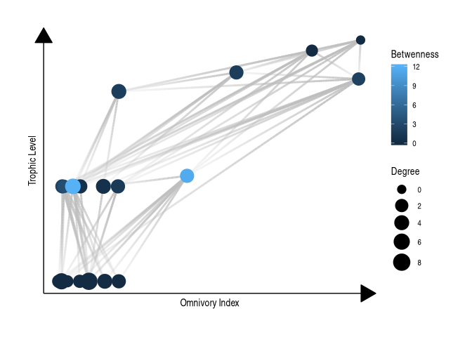

```r
data("TuesdayLakes_1984")

TuesdayLakes_1984 %>%
  plot_foodweb(dodge = 0.08)
```

Additional graphical elements can be addedd using the `ggraph` (and `ggplot2`) API.

```r
library(viridis)
```

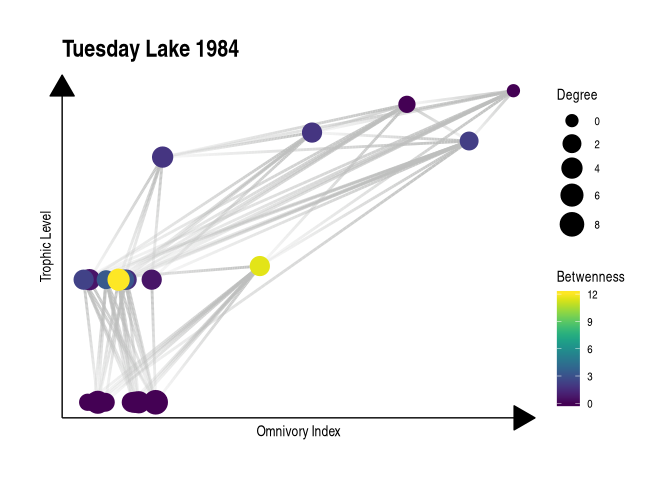

```r
library(ggraph)
TuesdayLakes_1984 %>%
  plot_foodweb(dodge = 0.08) +
  ggtitle("Tuesday Lake 1984") +
  scale_colour_viridis()
```

The underlying, more flexible, function is `ggfoodweb()`. It requires both a foodweb and a layout (that is, a matrix with two columns, specifying the x and y position of the specis in the plot). `ggfoodweb()` does not compute the layer for you, nor provides colour and size for the nodes. You can use `tl_oi_layer()` to compute a layout, and `fw_node_{size,colour}()` to define size and colour.

In the following example, we change size and colour with two different centralities, and place the species on the x axis following the order in which they are written in the network (this is usually a very BAD choice).

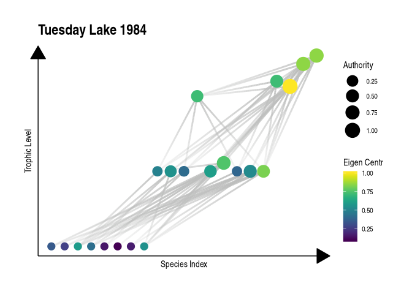

```r
default_layer <- tl_oi_layer(TuesdayLakes_1984, dodge = 0.04)

# we change the first column (horizontal position) to the row number of species
default_layer[,1] <- 1:nrow(default_layer)


TuesdayLakes_1984 %>%
  fw_node_colour(tidygraph::centrality_eigen) %>%
  fw_node_size(tidygraph::centrality_authority) %>%
  ggfoodweb(default_layer) +
  # with ggfoodweb() we need to define the axis and guides labels by hand
  scale_x_continuous(name = "Species Index") +
  scale_y_continuous(name = "Trophic Level") +
  guides(size = guide_legend(title="Authority"),
         colour = guide_colourbar(title="Eigen Centr")) +
  ggtitle("Tuesday Lake 1984") +
  scale_colour_viridis()
```

### Code of Conduct and Contribution

Please note that the ‘unravel’ project is released with a Contributor Code of Conduct. By contributing to this project, you agree to abide by its terms.